# Geog533 Lab 9

Complete the following exercises in Chapter 9 (More on Regression) of the textbook pages 286-287.

## Question 1

This is Exercise 7 in Chapter 9 of the Textbook [R].

The following results were obtained from a regression of $n = 14$ housing prices (in dollars) on median family income, size of house, and size of lot:

|  | Sum of squares | df | Mean square | F |
| --- | --- | --- | --- | --- |
| Regression SS: | 4234 | 3 |  |  |
| Residual SS: | 3487 |  |  |  |
| Total SS: |  |  |  |  |

|  | Coefficient (b) | Standard error (sb) | VIF |
| --- | --- | --- | --- |
| Median family income | 1.57 | 0.34 | 1.3 |
| Size of house (sq.ft) | 23.4 | 11.2 | 2.9 |
| Size of lot (sq.ft) | -9.5 | 7.1 | 11.3 |
| Constant | 40,000 | 1000 |  |

### Question 1(a)

Fill in the blanks.

```r
n <- 14
MSS <- 4234
RSS <- 3487
TSS <- MSS + RSS  ## TSS = 7721
df1 <- 3
df2 <- n-1-df1  ## df2=10
msq1 <- MSS/df1  ## msq1 = 1411.33
msq2 <- RSS/df2  ## msq2 = 348.7
F.value <- msq1/msq2  ## F.value = 4.047
library(knitr)
col1 <- c("Regression SS:","Residual SS:","Total SS:")
col2 <- c("4234","3487","7721")
col3 <- c("3","10","13")
col4 <- c("1411.33","348.7","")
col5 <- c("4.047","","")
df <- cbind(col1,col2,col3,col4,col5)
colnames(df) <- c("","Sum of squares","df","Mean square","F")
kable(df)
```

|  | Sum of squares | df | Mean square | F |
| --- | --- | --- | --- | --- |
| Regression SS: | 4234 | 3 | 1411.33 | 4.047 |
| Residual SS: | 3487 | 10 | 348.7 |  |
| Total SS: | 7721 | 13 |  |  |

### Question 1(b)

What is the value of $r^2$?

```r
R2 <- MSS/TSS  ## R2=0.548
R2
```

```
[1] 0.5483746
```

### Question 1(c)

What is the standard error of the estimate?

```r
# use the euqation 8.24 on textbook page 236: se = sqrt(RSS/(n-2))
se <- sqrt(RSS/(n-4))  ## se = 18.67
se
```

```
[1] 18.67351
```

```r
se2 <- sqrt(msq2)
se2
```

```
[1] 18.67351
```

### Question 1(d)

Test the null hypothesis that $R^2 = 0$ by comparing the $F-statistic$ from the table with its critical value.

```r
F.critical <- qf(0.95,df1,df2)  ## F.critical = 3.708
if(F.value > F.critical) {print("We reject the null hypothesis")} else {"We accept the null hypothesis"}
```

```
[1] "We reject the null hypothesis"
```

```r
# F.value > F.critical, so we reject the null hypothesis.
```

### Question 1(e)

Are the coefficients in the direction you would hypothesize? If not, which coefficients are opposite in sign from what you would expect?

```r
## the coefficient of size of lot is not in the direction I would hypothesis.
```

### Question 1(f)

```r
## t.statistic = coefficient / standard error, see equation 8.25 on page 237
t.critical <- qt(0.975,df = df2)  ## t.critical = 2.228
t.critical2 <- qt(0.025,df = df2) ## t.critical2 = -2.228
t.income <- 1.57/0.34  ## t.income = 4.618
t.house <- 23.4/11.2  ## t.house = 2.089
t.lot <- -9.5/7.1 ## t.lot = -1.338
t.constant <- 40000/1000  ## t.constant = 40
```

### Question 1(g)

What do you conclude from the variance inflation factors (VIFs)? What (if any) modifications would you recommend in light of the VIFs?

```r
# The VIF of size of lot is 11.3 > 5, this indicates potential multicollinearity. I recommend remove this size of lot variable
```

### Question 1(h)

What is the predicted sales price of a house that is 1500 square feet, on a lot 60´×100´, and in a neighborhood where the median family income is $40,000?

```r
price <- 40000 +  1.57*40000 + 23.4*1500 + (-9.5)*6000  ## price = 80900
price
```

```
[1] 80900
```

## Question 2

This is Exercise 10 in Chapter 9 of the Textbook [R].

### Question 2(a)

Using R and the [Hypothetical UK Housing Prices dataset](http://spatial.binghamton.edu/geog533/data/UK_Housing.csv), construct a regression equation using housing price as the dependent variable, and bedrooms, bathrooms, date built, garage, fireplace, floor area, and whether the home is detached as the independent variables. Investigate the importance of multicollinearity and outliers. Comment on the weaknesses of this specification, and on the results.

```r
url = "http://spatial.binghamton.edu/geog533/data/UK_Housing.csv"
df <- read.csv(url,header = TRUE)
str(df)
```

```
'data.frame':   499 obs. of  16 variables:
 $ region       : int  6 6 6 1 5 6 1 1 6 6 ...
 $ price        : int  25500 17450 22450 22500 53500 48100 29250 35450 21500 28250 ...
 $ garage       : int  0 0 0 0 0 1 0 1 0 0 ...
 $ bedrooms     : int  3 1 2 2 3 2 3 3 2 1 ...
 $ bathrooms    : int  2 1 1 1 1 1 1 1 2 1 ...
 $ datebuilt    : int  1973 1982 1883 1912 1959 1952 1894 1975 1910 1900 ...
 $ floorarea    : num  70.4 40.9 78.6 81.9 83.9 ...
 $ detached     : int  0 0 0 0 0 0 0 0 0 0 ...
 $ fireplace    : int  0 0 1 0 0 0 0 0 0 0 ...
 $ agelessthan15: num  26.9 23.2 20.4 19.5 19.7 ...
 $ age65andover : num  8.5 16.7 15.8 15.8 18.6 ...
 $ nonwhite     : num  0.038 1.836 0.153 2.881 0.626 ...
 $ unemploy     : num  11.38 11.73 5.18 4.84 8.08 ...
 $ ownocc       : num  52.7 60.4 59.7 59 57.4 ...
 $ carsperhh    : num  0.583 0.402 0.952 0.745 0.587 0.849 0.178 0.501 0.772 0.277 ...
 $ manuf        : num  23.3 11.5 12.3 12.6 12.6 ...
```

```r
df <- df[,c(2:9)]
str(df)
```

```
'data.frame':   499 obs. of  8 variables:
 $ price    : int  25500 17450 22450 22500 53500 48100 29250 35450 21500 28250 ...
 $ garage   : int  0 0 0 0 0 1 0 1 0 0 ...
 $ bedrooms : int  3 1 2 2 3 2 3 3 2 1 ...
 $ bathrooms: int  2 1 1 1 1 1 1 1 2 1 ...
 $ datebuilt: int  1973 1982 1883 1912 1959 1952 1894 1975 1910 1900 ...
 $ floorarea: num  70.4 40.9 78.6 81.9 83.9 ...
 $ detached : int  0 0 0 0 0 0 0 0 0 0 ...
 $ fireplace: int  0 0 1 0 0 0 0 0 0 0 ...
```

```r
full.model <- lm(price ~ .,data = df)
summary(full.model)
```

```
Call:
lm(formula = price ~ ., data = df)

Residuals:
   Min     1Q Median     3Q    Max
-38150  -6933  -1086   6705  64014

Coefficients:
              Estimate Std. Error t value Pr(>|t|)
(Intercept) -256087.18   34854.98  -7.347 8.50e-13 ***
garage        10980.77    1274.94   8.613  < 2e-16 ***
bedrooms        686.01     742.27   0.924   0.3558
bathrooms      2637.29    1526.36   1.728   0.0846 .
datebuilt       130.36      17.84   7.306 1.12e-12 ***
floorarea       374.18      22.22  16.842  < 2e-16 ***
detached      13186.76    2346.12   5.621 3.19e-08 ***
fireplace     -3144.39    1227.89  -2.561   0.0107 *
---
Signif. codes:  0 ‘***’ 0.001 ‘**’ 0.01 ‘*’ 0.05 ‘.’ 0.1 ‘ ’ 1

Residual standard error: 11550 on 491 degrees of freedom
Multiple R-squared:  0.6967,    Adjusted R-squared:  0.6924
F-statistic: 161.1 on 7 and 491 DF,  p-value: < 2.2e-16
```

```r
confint(full.model)
```

```
                    2.5 %       97.5 %
(Intercept) -324570.49170 -187603.8776
garage         8475.77198   13485.7775
bedrooms       -772.41022    2144.4238
bathrooms      -361.71307    5636.2866
datebuilt        95.30054     165.4149
floorarea       330.52648     417.8313
detached       8577.07549   17796.4368
fireplace     -5556.95096    -731.8243
```

```r
anova(full.model)
```

```
Analysis of Variance Table

Response: price
           Df     Sum Sq    Mean Sq  F value    Pr(>F)
garage      1 6.7904e+10 6.7904e+10 509.2986 < 2.2e-16 ***
bedrooms    1 2.9877e+10 2.9877e+10 224.0863 < 2.2e-16 ***
bathrooms   1 2.6268e+09 2.6268e+09  19.7018 1.119e-05 ***
datebuilt   1 2.9363e+09 2.9363e+09  22.0234 3.498e-06 ***
floorarea   1 4.1488e+10 4.1488e+10 311.1715 < 2.2e-16 ***
detached    1 4.6599e+09 4.6599e+09  34.9508 6.336e-09 ***
fireplace   1 8.7433e+08 8.7433e+08   6.5577   0.01074 *
Residuals 491 6.5464e+10 1.3333e+08
---
Signif. codes:  0 ‘***’ 0.001 ‘**’ 0.01 ‘*’ 0.05 ‘.’ 0.1 ‘ ’ 1
```

```r
aov(full.model)
```

```
Call:
   aov(formula = full.model)

Terms:
                     garage    bedrooms   bathrooms   datebuilt   floorarea    detached   fireplace   Residuals
Sum of Squares  67903943547 29877053816  2626807680  2936340338 41487981582  4659933304   874333507 65464220157
Deg. of Freedom           1           1           1           1           1           1           1         491

Residual standard error: 11546.79
Estimated effects may be unbalanced
```

```r
library(car)
vif(full.model)
```

```
   garage  bedrooms bathrooms datebuilt floorarea  detached fireplace
 1.366464  1.704548  1.040451  1.321745  1.866295  1.236362  1.167944
```

```r
# garage  bedrooms bathrooms datebuilt floorarea  detached fireplace
# 1.366464  1.704548  1.040451  1.321745  1.866295  1.236362  1.167944
## the VIF of all variables are <5, this indicates no multicollinearity
cor(df)
```

```
               price       garage     bedrooms    bathrooms   datebuilt   floorarea   detached    fireplace
price      1.0000000  0.560907149  0.519904695  0.118148482  0.30676506  0.68375702  0.4403099 -0.176118323
garage     0.5609071  1.000000000  0.292615666 -0.009567011  0.31152330  0.31089713  0.2605972 -0.276406156
bedrooms   0.5199047  0.292615666  1.000000000  0.031303373  0.13286904  0.61146520  0.2405654 -0.007922679
bathrooms  0.1181485 -0.009567011  0.031303373  1.000000000  0.04584438  0.07505420  0.1678555  0.040197496
datebuilt  0.3067651  0.311523299  0.132869041  0.045844376  1.00000000 -0.08768784  0.2916842 -0.274611719
floorarea  0.6837570  0.310897131  0.611465205  0.075054202 -0.08768784  1.00000000  0.2320962  0.076574029
detached   0.4403099  0.260597219  0.240565403  0.167855543  0.29168422  0.23209616  1.0000000 -0.168347094
fireplace -0.1761183 -0.276406156 -0.007922679  0.040197496 -0.27461172  0.07657403 -0.1683471  1.000000000
```

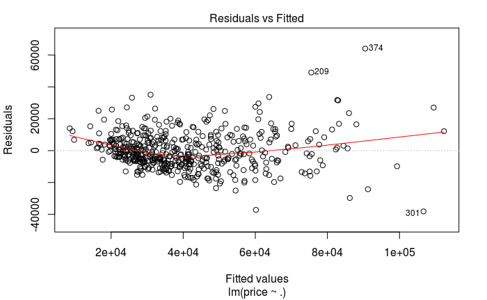

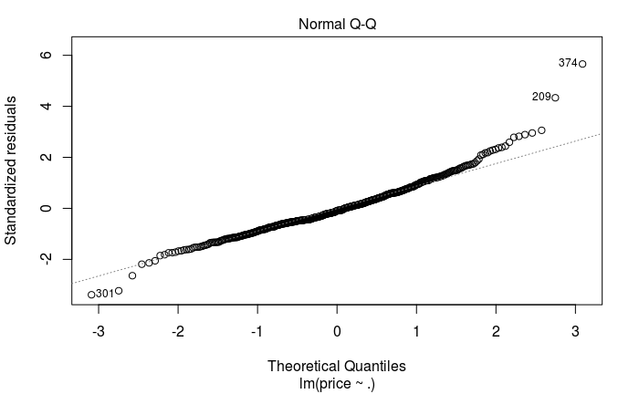

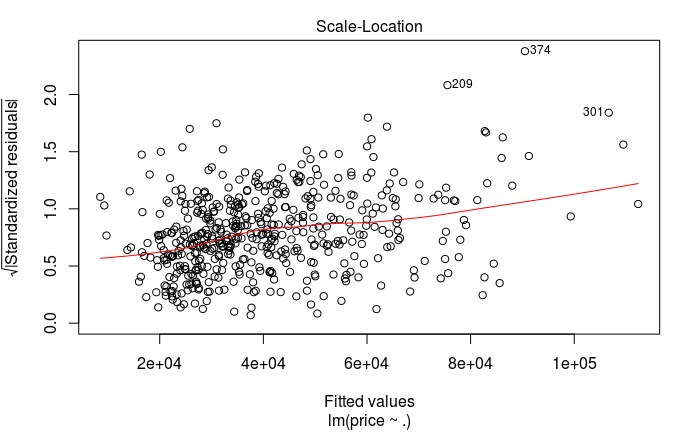

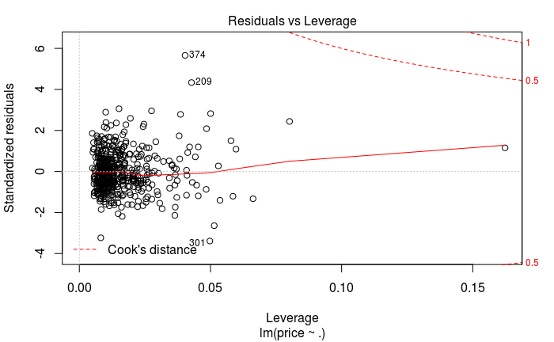

```r
plot(full.model)
```

```r
## plot the residual graph, we can see outlines 209, 374, 301
## weakness of the regression: bedrooms and bathrooms are insignificant.
```

### Question 2(b)

Attempt to improve the regression equation found in (a). Justify your decisions in constructing and carrying out the analysis.

```r
## improve the model by removing the insignificant variables found in (a)
new.model <- lm(price~garage + datebuilt + floorarea + detached + fireplace,data=df)
summary(new.model)
```

```
Call:
lm(formula = price ~ garage + datebuilt + floorarea + detached +
    fireplace, data = df)

Residuals:
   Min     1Q Median     3Q    Max
-37427  -7000  -1148   6312  62416

Coefficients:
              Estimate Std. Error t value Pr(>|t|)
(Intercept) -260574.57   34441.44  -7.566 1.91e-13 ***
garage        10913.99    1273.30   8.571  < 2e-16 ***
datebuilt       134.39      17.56   7.653 1.04e-13 ***
floorarea       387.53      18.19  21.304  < 2e-16 ***
detached      13935.26    2317.15   6.014 3.53e-09 ***
fireplace     -3016.56    1228.15  -2.456   0.0144 *
---
Signif. codes:  0 ‘***’ 0.001 ‘**’ 0.01 ‘*’ 0.05 ‘.’ 0.1 ‘ ’ 1

Residual standard error: 11570 on 493 degrees of freedom
Multiple R-squared:  0.6944,    Adjusted R-squared:  0.6913
F-statistic:   224 on 5 and 493 DF,  p-value: < 2.2e-16
```

## Question 3

This is Exercise 11 in Chapter 9 of the Textbook [R].

### Question 3(a)

Using R and the [Milwaukee dataset](http://spatial.binghamton.edu/geog533/data/Milwaukee_Sales.csv) described in Section 1.9.2, construct a regression equation using housing sales price as the dependent variable, and number of bedrooms, lot size, finished square footage in the house, age of house, and number of bathrooms, as the independent variables. Investigate the importance of multicollinearity and outliers. Comment on the weaknesses of this specification, and on the results.

```r
url = "http://spatial.binghamton.edu/geog533/data/Milwaukee_Sales.csv"
df <- read.csv(url, header = TRUE)
str(df)
```

```
'data.frame':   1449 obs. of  16 variables:
 $ Stories         : num  1 1 1 1 1 1 1 1 2 2 ...
 $ FinSqft         : int  1560 1538 1359 1339 1213 1206 1062 1033 1664 1237 ...
 $ Bedrms          : int  4 3 3 3 3 3 3 3 3 4 ...
 $ Baths           : num  1.5 1.5 1 2.5 1 1 1.5 1 2.5 1.5 ...
 $ LotSize         : int  4680 7100 5040 5000 5125 5880 7560 5320 7800 5542 ...
 $ SaleDate        : Factor w/ 12 levels "2012-01","2012-02",..: 4 6 7 3 9 1 4 4 10 2 ...
 $ SalePrice       : int  61000 85900 87500 89900 64500 35000 74700 71000 127500 73027 ...
 $ Ald             : int  1 1 1 1 1 1 1 1 1 1 ...
 $ Age             : int  76 65 72 70 61 72 71 67 63 42 ...
 $ FullBase        : int  1 1 0 1 1 1 1 1 1 1 ...
 $ Attic           : int  1 1 1 1 1 1 1 1 0 0 ...
 $ FIREPLACE       : int  0 1 0 0 0 0 0 0 1 0 ...
 $ AIR_CONDITIONING: int  0 1 1 1 1 1 0 0 1 0 ...
 $ Garage          : int  1 1 1 1 1 1 1 1 1 1 ...
 $ X               : num  2551960 2543593 2553561 2551449 2541430 ...
 $ Y               : num  405664 416385 412894 408569 412143 ...
```

```r
full.model <- lm(SalePrice ~ Bedrms + LotSize + FinSqft + Age + Baths, data = df)
summary(full.model)
```

```
Call:
lm(formula = SalePrice ~ Bedrms + LotSize + FinSqft + Age + Baths,
    data = df)

Residuals:
    Min      1Q  Median      3Q     Max
-243841  -29791    2824   28372  460759

Coefficients:
              Estimate Std. Error t value Pr(>|t|)
(Intercept)  2.624e+04  9.420e+03   2.786  0.00541 **
Bedrms      -2.876e+04  2.372e+03 -12.122  < 2e-16 ***
LotSize      3.580e+00  6.442e-01   5.557 3.26e-08 ***
FinSqft      1.007e+02  4.535e+00  22.210  < 2e-16 ***
Age         -1.306e+02  7.629e+01  -1.712  0.08711 .
Baths        2.302e+04  3.698e+03   6.225 6.29e-10 ***
---
Signif. codes:  0 ‘***’ 0.001 ‘**’ 0.01 ‘*’ 0.05 ‘.’ 0.1 ‘ ’ 1

Residual standard error: 60990 on 1443 degrees of freedom
Multiple R-squared:  0.4867,    Adjusted R-squared:  0.4849
F-statistic: 273.6 on 5 and 1443 DF,  p-value: < 2.2e-16
```

```r
library(car)
vif(full.model)
```

```
  Bedrms  LotSize  FinSqft      Age    Baths
2.020048 1.254748 3.110106 1.352311 2.087716
```

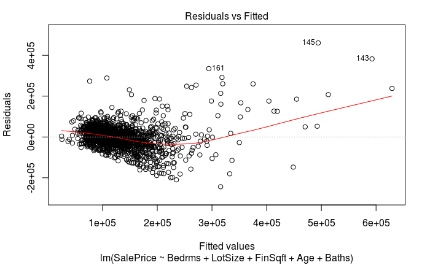

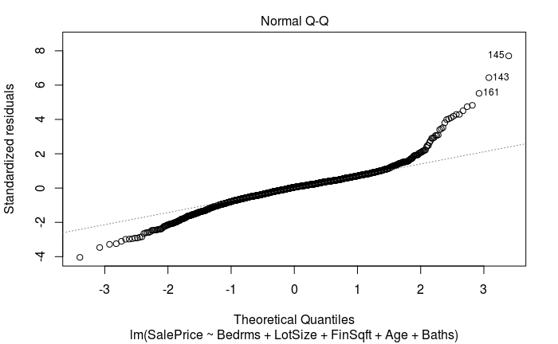

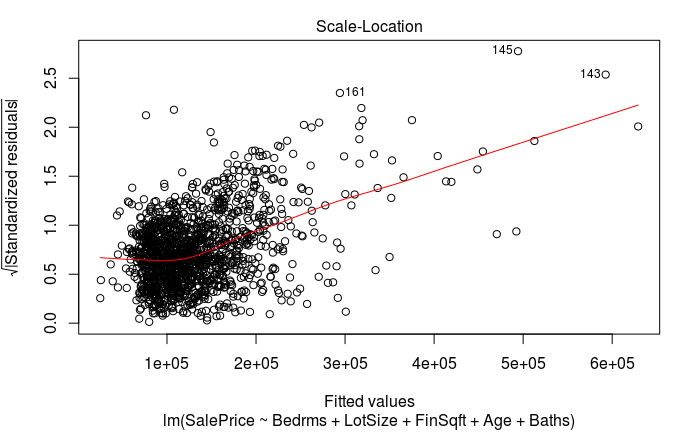

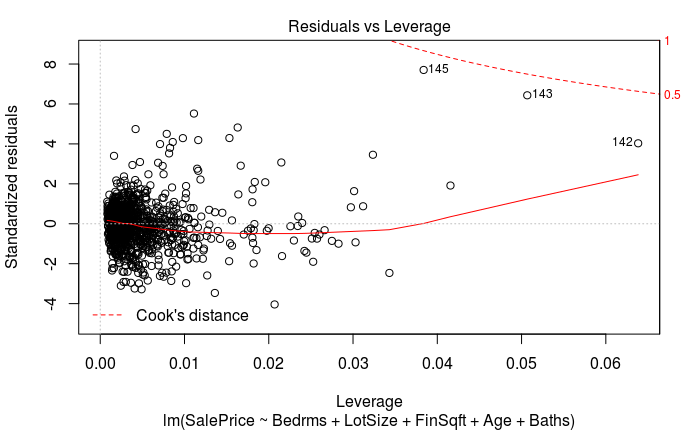

```r
# Bedrms  LotSize  FinSqft      Age    Baths
# 2.020048 1.254748 3.110106 1.352311 2.087716
# The VIFs of all variables are < 5, this indicates no multicollinearity
plot(full.model)
```

```r
# by checking the residual plot, there are outliers 161, 145, 143
# Estimate Std. Error t value Pr(>|t|)
# (Intercept)  2.624e+04  9.420e+03   2.786  0.00541 **
#   Bedrms      -2.876e+04  2.372e+03 -12.122  < 2e-16 ***
#   LotSize      3.580e+00  6.442e-01   5.557 3.26e-08 ***
#   FinSqft      1.007e+02  4.535e+00  22.210  < 2e-16 ***
#   Age         -1.306e+02  7.629e+01  -1.712  0.08711 .
# Baths        2.302e+04  3.698e+03   6.225 6.29e-10 ***
## the vairable age of house is insignificant.
```

### Question 3(b)

Attempt to improve the regression equation found in (a). Justify your decisions in constructing and carrying out the analysis.

```r
# improve the model by removing the insignificant variable age
new.model <- lm(SalePrice ~ Bedrms + LotSize + FinSqft + Baths, data = df)
summary(new.model)
```

```
Call:
lm(formula = SalePrice ~ Bedrms + LotSize + FinSqft + Baths,
    data = df)

Residuals:
    Min      1Q  Median      3Q     Max
-246321  -29808    2642   29036  456835

Coefficients:
              Estimate Std. Error t value Pr(>|t|)
(Intercept)  1.544e+04  6.995e+03   2.206   0.0275 *
Bedrms      -2.870e+04  2.374e+03 -12.090  < 2e-16 ***
LotSize      4.058e+00  5.808e-01   6.987 4.28e-12 ***
FinSqft      9.849e+01  4.346e+00  22.659  < 2e-16 ***
Baths        2.401e+04  3.656e+03   6.568 7.08e-11 ***
---
Signif. codes:  0 ‘***’ 0.001 ‘**’ 0.01 ‘*’ 0.05 ‘.’ 0.1 ‘ ’ 1

Residual standard error: 61030 on 1444 degrees of freedom
Multiple R-squared:  0.4857,    Adjusted R-squared:  0.4842
F-statistic: 340.9 on 4 and 1444 DF,  p-value: < 2.2e-16
```

```r
# Estimate Std. Error t value Pr(>|t|)
# (Intercept)  1.544e+04  6.995e+03   2.206   0.0275 *
#   Bedrms      -2.870e+04  2.374e+03 -12.090  < 2e-16 ***
#   LotSize      4.058e+00  5.808e-01   6.987 4.28e-12 ***
#   FinSqft      9.849e+01  4.346e+00  22.659  < 2e-16 ***
#   Baths        2.401e+04  3.656e+03   6.568 7.08e-11 ***
```